# Maintain your brain, MediCul

## MEDICULTotal

- Secondary Outcome: MEDICUL Total

These results exclude those participants who were eligible for fewer than 2 modules but who were randomised. This results in N=6104.

```r
# read in functions and data
source("functions.R")
myb_dat <- read.csv(paste0("../../Data/",params$data,".csv"))
```

Inference for differences in rc_trial_time trend by group_type_id for MEDICULTotal

## Data summary

```r
myb_dat %>%
  group_by(.dots = lapply(params$predictors, as.symbol)) %>%
  summarize_at(.vars = params$response, .funs = list(Mean = mean, Sd = sd, N_obs = ~length(.)), na.rm=T)
```

```
## # A tibble: 8 x 5
## # Groups:   rc_trial_time [4]
##   rc_trial_time group_type_id  Mean    Sd N_obs
##           <int>         <int> <dbl> <dbl> <int>
## 1             1             1  53.3  12.6  3053
## 2             1             2  52.8  12.6  3051
## 3            10             1  54.9  12.7  2231
## 4            10             2  63.8  14.6  1549
## 5            11             1  54.8  12.6  1985
## 6            11             2  64.2  14.3  1396
## 7            12             1  54.5  12.7  2036
## 8            12             2  63.7  14.5  1401
```

```r
# if want to run
if(!params$final){

  # run models
  fitted_mods <- MYB_fit(params$response, params$predictors,
                       params$covariates, params$id, myb_dat, times = plannedtimes)
  # save models
  save(fitted_mods,file = paste0("../../Results/baseline_sd/",params$response))

} else {
  load(file = paste0("../../Results/baseline_sd/",params$response))
}
```

```r
#plot models

if(!params$final){
  lapply(fitted_mods, plot, form = cond)
}
```

```r
#check summary is okay

if(!params$final){
  lapply(fitted_mods, summary)
}
```

## Results

```r
if(!params$final){

  # calculate CI
  res_tab = MYB_inf(fitted_mods, params$response)

  # save models
  write.csv(res_tab,file = paste0("../../Results/baseline_sd/",params$response,"_table.csv"), row.names = FALSE)



} else {
  res_tab <- read.csv(file = paste0("../../Results/baseline_sd/",params$response,"_table.csv"))


}

res <- res_tab %>%
  transmute(response,
            adjusted,
            base_3yr_did = round(planned,3),
            LCL = round(asymp.LCL,3),
            UCL = round(asymp.UCL,3),
            zstat,
            pz,
            Chisq,
            `p.value` = ifelse (`p.value` < 0.001, "<0.001",paste("= ",round(`p.value`,3)))
)

res
```

```
##       response adjusted base_3yr_did   LCL   UCL  zstat     pz       Chisq
## 1 MEDICULTotal       No        8.720 8.169 9.271 31.007 <0.001 1454.265(3)
## 2 MEDICULTotal      Yes        8.656 8.107 9.206 30.885 <0.001  1449.15(3)
##   p.value
## 1  <0.001
## 2  <0.001
```

```r
evidence_unadj = ifelse(res_tab$p.value[1]<0.05, "evidence", "no evidence")
evidence_adj = ifelse(res_tab$p.value[2]<0.05, "evidence", "no evidence")

# baseline pooled SD
temp <- myb_dat %>%
  filter(rc_trial_time==1) %>%
  dplyr::select(MEDICULTotal)
baselinesd<-sd(temp$MEDICULTotal)
es<-round(res_tab[1,3] / sd(temp$MEDICULTotal),3)
esadj<-round(res_tab[2,3] / sd(temp$MEDICULTotal),3)
rm(temp)
```

NOTE: MEDICUL is not baseline-standardised, so these results can be intepreted as:

group_type_id=2 showed a greater change of 8.720 points (unadjusted) on the MEDICUL than group_type_id=1 from baseline to 3 years.

However, we can calculate an effect size from the raw difference in differences and pooled baseline SD:

$$ES = \frac{DID}{Baseline SD}$$
$$ES_{unadj} = \frac{8.720}{12.627} =
0.691$$

$$ES_{adj} = \frac{8.657}{12.627} =
0.686$$

So, the change from baseline to three years was 0.691 baseline SDs higher in group 2 than group 1 (unadjusted).

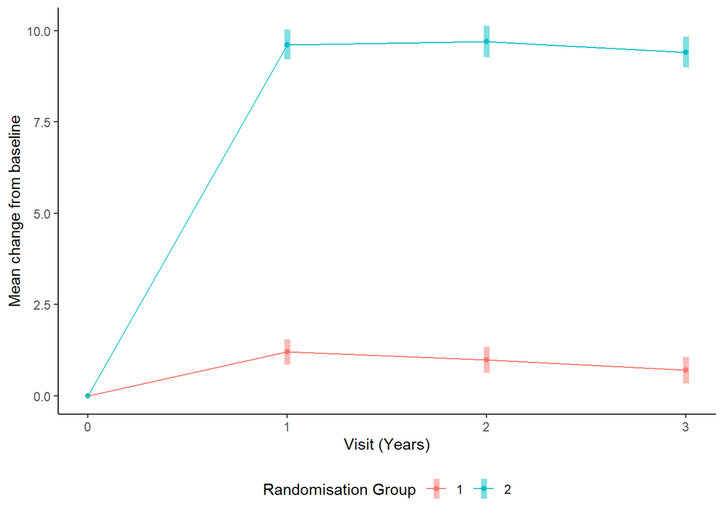

## Result

Covariates included in adjusted models:

- `myb_age`: Age at Baseline
- `myb_gender`: Reported gender
- `cl_edu_yrs`: Years of education
- `rcal_modules_sum`: Number of modules person was eligible for
- `adri_baseline`: ADRI at Baseline

A linear mixed model with a random effect for individual and fixed effects of time point, randomisation group and their interaction was run. An additional analysis including covariates of myb_age, myb_gender, cl_edu_yrs, rcal_modules_sum, adri_baseline was run. We report estimates of the group difference in the change from baseline to three years follow up with 95% confidence interval, and associated Z statistic and p-value. The units of the effect size are standard deviations at baseline.

Analysis by Nancy Briggs and Gordana Popovic on 2024-02-14